# Analise_bibliometrica

[figure not shown]

**Mestrado em Ciência de Dados para Ciências Sociais**

**Universidade de Aveiro**

Introdução à Ciência de Dados - 2024/2025

Magda Matias | N.º Mec.: 50091  
Rita Gonçalves | N.º Mec.: 30099

## 1. Definição do tema

A Inteligência Artificial (IA) é uma tecnologia que está a ser amplamente aplicada em várias áreas. A investigação científica é uma das áreas que poderá ser mais significativamente impactada pela IA, pelo potencial que ela significa no aceleramento da descoberta científica, no aumento da eficácia e do ritmo dos processos de investigação (European Commission, 2024). A IA é utilizada pelos cientistas para gerar hipóteses, conceber experiências, recolher e interpretar dados de formas que anteriormente não eram possíveis apenas com os métodos tradicionais (Erduran & Levrini, 2024). Para além das vantagens que pode significar, o uso de ferramentas de IA também origina desafios e levanta questões relacionadas com a ética, a transparência, os direitos de autor, entre outras.

O objetivo deste trabalho é fazer uma recolha de literatura científica que aborde o impacto, o uso e o papel da IA na investigação científica e a partir desse conjunto de publicações efetuar uma análise bibliométrica (incluindo, nomeadamente, as áreas disciplinares, os países e os anos mais representados) e uma análise de conteúdo (incluindo, nomeadamente, a identificação dos tópicos mais abordados).

#### Referências bibliográficas

Erduran, S., & Levrini, O. (2024). The impact of artificial intelligence on scientific practices: an emergent area of research for science education. *International Journal of Science Education*. https://doi.org/10.1080/09500693.2024.2306604

European Commission. (2024). *Living guidelines on the responsible use of generative AI in research*. European Union. https://research-and-innovation.ec.europa.eu/document/2b6cf7e5-36ac-41cb-aab5-0d32050143dc_en

## 2. Recolha de informação

### Fontes

A fonte selecionada para a pesquisa bibliográfica foi a base de dados multidisciplinar [Scopus](https://www.scopus.com/search/form.uri?display=basic#basic).

### *Queries*

Para a pesquisa bibliográfica foram usados os termos "artificial intelligence", "scientific research" e “impact”, resultando na seguinte expressão de pesquisa:  
`(TITLE-ABS-KEY("artificial intelligence") AND TITLE-ABS-KEY("scientific research") AND TITLE-ABS-KEY("impact`"))

## 3. Análise de indicadores bibliométricos

### Setup

```python
import time
import os
import sys
import requests
import json
import pickle
import math
import pandas as pd
import matplotlib.pyplot as plt
import seaborn as sns
import numpy as np
import wordcloud
from wordcloud import WordCloud
import geopandas as gpd
```

### Leitura de CSV

A análise bibliométrica foi realizada com base em ficheiros .CSV exportados da Scopus.

```python
df=pd.read_csv('scopus.csv')
```

```python
df1=pd.read_csv('scopus.csv')
```

```python
df_subject = pd.read_csv('Scopus-Subject.csv')
```

```python
df_country = pd.read_csv('Scopus-Country.csv')
```

```python
df.head(2)
```

|  | Authors | Author full names | Author(s) ID | Title | Year | Source title | Volume | Issue | Art. No. | Page start | ... | ISBN | CODEN | PubMed ID | Language of Original Document | Abbreviated Source Title | Document Type | Publication Stage | Open Access | Source | EID |
| --- | --- | --- | --- | --- | --- | --- | --- | --- | --- | --- | --- | --- | --- | --- | --- | --- | --- | --- | --- | --- | --- |
| 0 | Grüger H.; Knobbe J.; Pügner T. | Grüger, Heinrich (6602682760); Knobbe, Jens (6... | 6602682760; 6506736925; 34168234400 | Multi- and hyperspectral imaging of plants and... | 2024 | Proceedings of SPIE - The International Societ... | 12879 | NaN | 1287903 | NaN | ... | 978-151067018-1 | PSISD | NaN | English | Proc SPIE Int Soc Opt Eng | Conference paper | Final | NaN | Scopus | 2-s2.0-85190967516 |
| 1 | Pazo M.; Gerassis S.; Araújo M.; Margarida Ant... | Pazo, M. (57240871600); Gerassis, S. (57193055... | 57240871600; 57193055708; 36560944600; 5898070... | Enhancing water quality prediction for fluctua... | 2024 | Science of the Total Environment | 927 | NaN | 172340 | NaN | ... | NaN | STEVA | 38608909.0 | English | Sci. Total Environ. | Article | Final | All Open Access; Hybrid Gold Open Access | Scopus | 2-s2.0-85190066682 |

2 rows × 34 columns

```python
df.columns
```

```
Index(['Authors', 'Author full names', 'Author(s) ID', 'Title', 'Year',
       'Source title', 'Volume', 'Issue', 'Art. No.', 'Page start', 'Page end',
       'Page count', 'Cited by', 'DOI', 'Link', 'Affiliations',
       'Authors with affiliations', 'Abstract', 'Author Keywords',
       'Index Keywords', 'Correspondence Address', 'Editors', 'Publisher',
       'ISSN', 'ISBN', 'CODEN', 'PubMed ID', 'Language of Original Document',
       'Abbreviated Source Title', 'Document Type', 'Publication Stage',
       'Open Access', 'Source', 'EID'],
      dtype='object')
```

### Sumário

#### **Quantos?**

Análise de contagens e distribuição de documentos por autores, número de citações, nível de acesso e área temática.

- **Total de documentos**: número de documentos resultantes da pesquisa bibliográfica e objeto de análise.
- **Autores mais produtivos**: identificação dos autores mais produtivos, através do campo `Authors`.
- **Documentos mais citados**: identificação dos artigos com maior impacto, através do campo `Cited by`.
- **Documentos em Acesso Aberto**: número de documentos disponíveis em qualquer tipo de Acesso Aberto, através do campo `Open Access`.
- **Documentos por área temática**: número de documentos por área científica, através do campo `Subject Area` de um ficheiro próprio exportado da Scopus.

#### **Quando?**

Análise das tendências ao longo do tempo em termos de volume de publicação, número de citações e nível de acesso.

- **Documentos por ano**: número de documentos publicados por ano, através do campo `Year`.
- **Citações por ano**: número de citações por ano, através dos campos `Year` e `Cited by`.
- **Documentos por nível de acesso (Aberto vs. Fechado) e por ano**: número de documentos publicados em Acesso Aberto e em Acesso Fechado por ano, através dos campos `Year` e `Open Access`.
- **Citações por nível de acesso (Aberto vs. Fechado) e por ano**: número de citações de documentos em Acesso Aberto e em Acesso Fechado por ano, através dos campos `Year` e `Cited by`.

#### **Onde?**

Análise das fontes, instituições/afiliações e locais de publicação mais representados de forma a compreender onde se concentra a investigação.

- **Principais fontes**: identificação das fontes onde foram publicados mais documentos, através do campo `Source title`.
- **Principais instituições/afiliações**: identificação das instituições mais ativas, através do campo `Affiliations`.
- **Fontes mais citadas**: identificação das fontes com mais citações, através dos campos `Source title` e `Cited by`.
- **Distribuição geográfica dos documentos**: identificação dos países com mais documentos publicados, através do campo `Country` de um ficheiro próprio exportado da Scopus.

#### **O quê?**

Análise dos tipos de documentos, palavras-chave e termos de pesquisa mais frequentes.

- **Documentos por tipologia**: número de documentos por tipologia, através do campo `Document Type`.
- **Principais palavras-chave de autor**: identificação das palavras-chave de autor mais frequentes, através do campo `Author Keywords`.
- **Principais palavras-chave de indexação**: identificação das palavras-chave de indexação mais frequentes, através do campo `Index Keywords`.
- **Termos de pesquisa no campo Título**: número de vezes em que os termos de pesquisa surgem no título, através do campo `Title`.

### 3.1. Quantos?

Nesta secção apresenta-se o número total de documentos resultantes da pesquisa bibliográfica e analisa-se a distribuição de documentos por autores, número de citações, nível de acesso e área temática.

```python
# Número total de documentos
total_articles = df.shape[0]
print(f"Número total de documentos: {total_articles}")
```

```
Número total de documentos: 243
```

```python
# Top 10 de documentos mais citados
top_cited_articles = df[['Title', 'Cited by']].sort_values(by='Cited by', ascending=False).head(10)
print("Top 10 de documentos mais citados:")
print(top_cited_articles)
```

```
Top 10 de documentos mais citados:
                                                 Title  Cited by
161  ChatGPT and the rise of large language models:...       229
206  Improved prediction of harmful algal blooms in...       126
221  Missing data imputation by K nearest neighbour...       126
122  Impacts of climate variability and drought on ...        89
205  Web Intelligence and Artificial Intelligence i...        70
184  Artificial Intelligence Regulation: a framewor...        69
215      Web Intelligence (WI): What makes wisdom web?        62
188  QuPath: The global impact of an open source di...        60
157  Thoughts on the Development of Frontier Techno...        50
201  The Top 100 Articles in the Medical Informatic...        39
```

```python
# Top 10 de autores mais produtivos:
author_counts = df['Authors'].str.split('; ').explode().value_counts().head(10)
print("Top 10 de autores mais produtivos:")
print(author_counts)
```

```
Top 10 de autores mais produtivos:
Authors
Wang Y.     10
Zhang X.     6
Zhang Z.     5
Liu Y.       5
Li J.        5
Liu S.       3
Sun J.       3
Chen Y.      3
Zhang P.     3
Wang J.      3
Name: count, dtype: int64
```

```python
# Número de documentos em Acesso Aberto
open_access_counts = df['Open Access'].value_counts()
print("Número de documentos em Acesso Aberto ")
print(open_access_counts)
```

```
Número de documentos em Acesso Aberto
Open Access
All Open Access; Gold Open Access                              51
All Open Access; Hybrid Gold Open Access                       18
All Open Access; Gold Open Access; Green Open Access           10
All Open Access; Bronze Open Access                             7
All Open Access; Green Open Access                              4
All Open Access; Green Open Access; Hybrid Gold Open Access     1
All Open Access; Bronze Open Access; Green Open Access          1
Name: count, dtype: int64
```

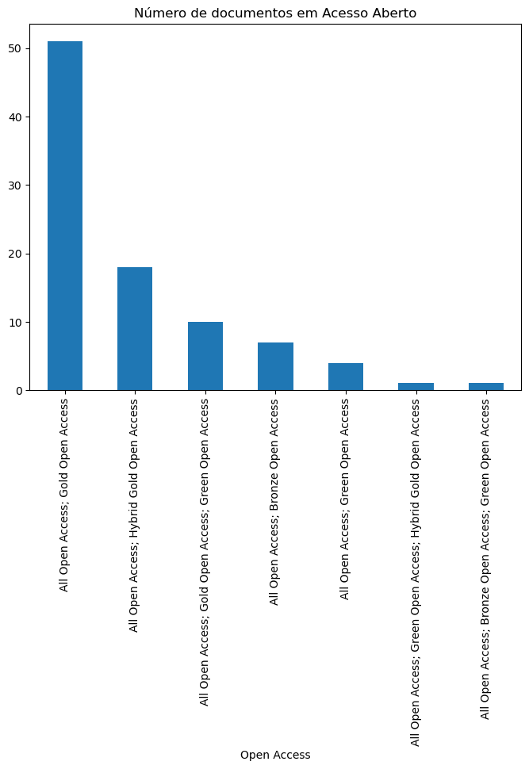

```python
# Mostrar gráfico de barras
plt.figure(figsize=(8, 6))
plt.xticks(rotation=45)
plt.title("Número de documentos em Acesso Aberto")
open_access_counts.plot(kind='bar')
```

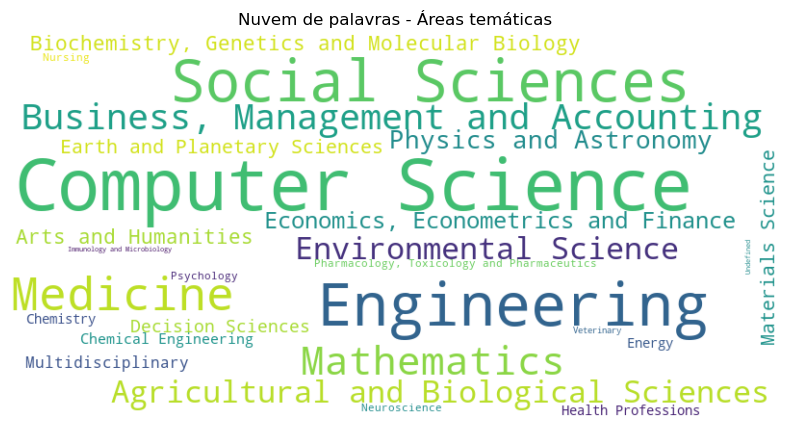

```python
# Número de documentos por área temática
word_freq=dict(zip(df_subject['SUBJECT AREA'], df_subject['NR']))

nuvem=WordCloud(width=800, height=400, background_color='white').generate_from_frequencies(word_freq)

plt.figure(figsize=(10, 5))
plt.imshow(nuvem, interpolation='bilinear')
plt.axis('off')
plt.title("Nuvem de palavras - Áreas temáticas")
plt.show()
```

### 3.2. Quando?

Nesta secção são analisados alguns dos aspetos temporais dos dados, nomeadamente as tendências ao longo dos anos em termos de volume de publicação, número de citações e nível de acesso.

```python
df['Year']
```

```
0      2024
1      2024
2      2024
3      2024
4      2024
       ...
238    2018
239    2019
240    2020
241    2003
242    2020
Name: Year, Length: 243, dtype: int64
```

```python
# Número de documentos por ano
yearly_publications = df['Year'].value_counts().sort_index()
print("Número de documentos por ano:")
print(yearly_publications)
```

```
Número de documentos por ano:
Year
1990     1
2003     2
2004     3
2005     1
2006     1
2007     1
2008     2
2011     2
2012     2
2014     3
2015     3
2017     4
2018     7
2019     5
2020    11
2021    29
2022    25
2023    50
2024    91
Name: count, dtype: int64
```

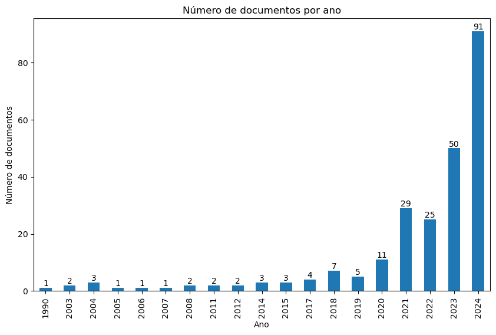

```python
# Mostrar gráfico
plt.figure(figsize=(10, 6))
ax = yearly_publications.plot(kind='bar', title='Número de documentos por ano')
plt.xlabel("Ano")
plt.ylabel("Número de documentos")

# Adicionar etiquetas/legenda
ax.bar_label(ax.containers[0])

plt.show()
```

```
Número de citações por ano:
Year
1990      6
2003     68
2004     74
2005      2
2006      0
2007      0
2008      6
2011      0
2012     22
2014      6
2015    126
2017     76
2018    178
2019     49
2020    169
2021    315
2022    141
2023    545
2024    107
Name: Cited by, dtype: int64
```

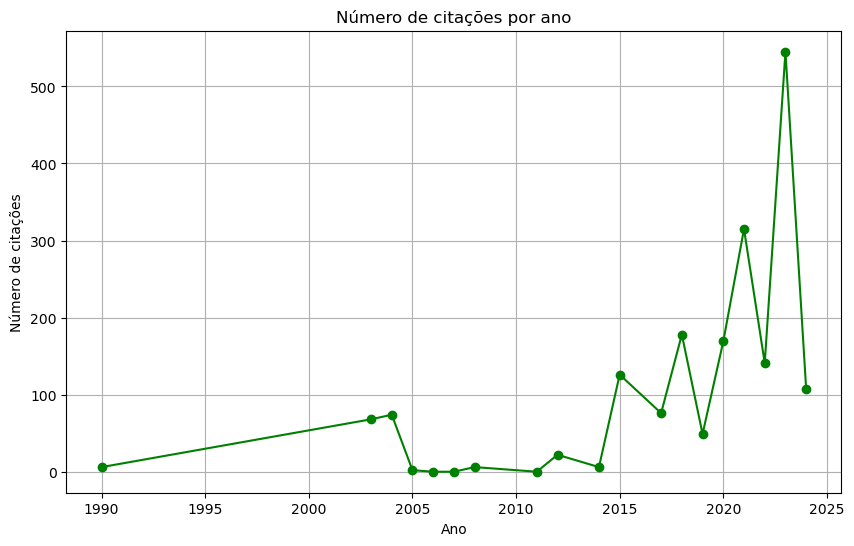

```python
df['Year'] = pd.to_numeric(df['Year'], errors='coerce')  # Converter anos para numérico
df['Cited by'] = pd.to_numeric(df['Cited by'], errors='coerce')  # Converter citações para numérico

# Somatório de citações por ano
citations_per_year = df.groupby('Year')['Cited by'].sum()

#Tabela gráfica com totais de citações por ano
print("Número de citações por ano:")
result_python = df.groupby('Year')['Cited by'].sum()
print(result_python)

# Gráfico de citações por ano
plt.figure(figsize=(10, 6))
citations_per_year.plot(kind='line', marker='o', color='green', title='Número de citações por ano')
plt.xlabel("Ano")
plt.ylabel("Número de citações")
plt.grid(True)
plt.show()
```

```python
# Display unique values in 'Open Access' column to check for inconsistencies
print(df['Open Access'].unique())
```

```
[nan 'All Open Access; Hybrid Gold Open Access'
 'All Open Access; Gold Open Access' 'All Open Access; Green Open Access'
 'All Open Access; Bronze Open Access'
 'All Open Access; Gold Open Access; Green Open Access'
 'All Open Access; Green Open Access; Hybrid Gold Open Access'
 'All Open Access; Bronze Open Access; Green Open Access']
```

[figure not shown]

```python
# Criar uma coluna "binária" para indicar o nível de Acesso Aberto
df['Is Open Access'] = df['Open Access'].str.contains("all open access", na=True)

# Agrupar por ano e contar o número de documentos que estão com o nível de Acesso Aberto
documents_by_access = df.groupby(['Year', 'Is Open Access']).size().unstack(fill_value=0)

# Mostrar gráfico
plt.figure(figsize=(10, 6))
documents_by_access.plot(kind='line', marker='o', title='Número de documentos por nível de acesso e por ano')
plt.xlabel("Ano")
plt.ylabel("Número de documentos")
plt.legend(["Acesso fechado", "Acesso aberto"], title="Nível de acesso:")
plt.show()
```

[figure not shown]

```python
# Criar uma coluna "binária" para indicar o nível de Acesso Aberto
df['Is Open Access'] = df['Open Access'].str.contains("all open access", na=True)

# Agrupar por ano e contar o número de citações que estão com o nível de Acesso Aberto
citations_by_access = df.groupby(['Year', 'Is Open Access'])['Cited by'].sum().unstack(fill_value=0)

# Mostrar gráfico
plt.figure(figsize=(10, 6))
citations_by_access.plot(kind='line', marker='o', title='Número de citações por nível de acesso e por ano')
plt.xlabel("Ano")
plt.ylabel("Número de citações")
plt.legend(["Acesso fechado", "Acesso aberto"], title="Nível de acesso")
plt.show()
```

### 3.3. Onde?

Esta secção foca os locais onde a investigação foi publicada e produzida, analisando as fontes onde os documentos foram publicados, assim como as instituições de origem dos autores e os países associados aos documentos.

```python
df.columns
```

```
Index(['Authors', 'Author full names', 'Author(s) ID', 'Title', 'Year',
       'Source title', 'Volume', 'Issue', 'Art. No.', 'Page start', 'Page end',
       'Page count', 'Cited by', 'DOI', 'Link', 'Affiliations',
       'Authors with affiliations', 'Abstract', 'Author Keywords',
       'Index Keywords', 'Correspondence Address', 'Editors', 'Publisher',
       'ISSN', 'ISBN', 'CODEN', 'PubMed ID', 'Language of Original Document',
       'Abbreviated Source Title', 'Document Type', 'Publication Stage',
       'Open Access', 'Source', 'EID', 'Is Open Access'],
      dtype='object')
```

```
Fontes principais
Source title
Lecture Notes in Computer Science (including subseries Lecture Notes in Artificial Intelligence and Lecture Notes in Bioinformatics)    6
ACM International Conference Proceeding Series                                                                                          5
Proceedings of SPIE - The International Society for Optical Engineering                                                                 3
Journal of Physics: Conference Series                                                                                                   3
Lecture Notes in Networks and Systems                                                                                                   2
Lecture Notes in Electrical Engineering                                                                                                 2
Scientometrics                                                                                                                          2
Heliyon                                                                                                                                 2
Encuentros (Maracaibo)                                                                                                                  2
Journal of Medical Systems                                                                                                              2
Lecture Notes in Civil Engineering                                                                                                      2
2011 2nd International Conference on Artificial Intelligence, Management Science and Electronic Commerce, AIMSEC 2011 - Proceedings     2
Kexue Tongbao/Chinese Science Bulletin                                                                                                  2
Intelligent Systems Reference Library                                                                                                   2
IEEE Access                                                                                                                             2
Name: count, dtype: int64
```

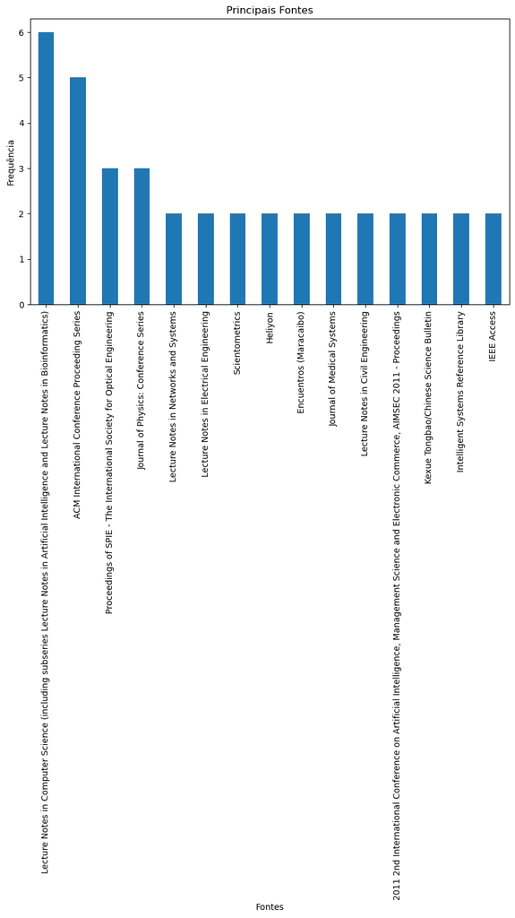

```python
# Principais fontes
df['Source title'] = df['Source title'].fillna('')
all_sources = df['Source title'].str.split('; ').explode().value_counts().head(15)
print("Fontes principais")
print(all_sources)

# Mostrar o top 10 de tipos de documento
plt.figure(figsize=(10, 6))
all_sources.plot(kind='bar', title='Principais Fontes')
plt.xlabel("Fontes")
plt.ylabel("Frequência")
plt.show()
```

```python
# Fontes mais citadas
journal_citations = df.groupby('Source title')['Cited by'].sum().sort_values(ascending=False).head(10)
print("Top 10 de fontes mais citadas:")
print(journal_citations)
```

```
Top 10 de fontes mais citadas:
Source title
Frontiers in Public Health                                              229
International Journal of Environmental Research and Public Health       126
Applied Intelligence                                                    126
Remote Sensing                                                           89
Educational Technology and Society                                       70
Ethics and Information Technology                                        69
IJCAI International Joint Conference on Artificial Intelligence          62
Computational and Structural Biotechnology Journal                       60
Diangong Jishu Xuebao/Transactions of China Electrotechnical Society     50
Journal of Medical Systems                                               42
Name: Cited by, dtype: int64
```

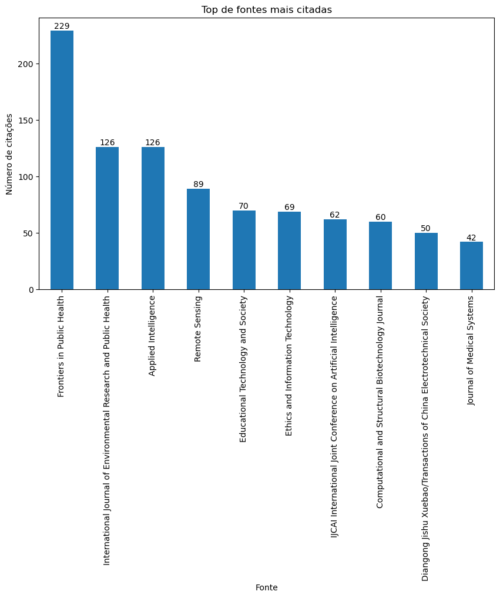

```python
# Gráfico das revistas mais citadas
plt.figure(figsize=(10, 6))
ax = journal_citations.plot(kind='bar', title='Top de fontes mais citadas')
plt.xlabel("Fonte")
plt.ylabel("Número de citações")

# Adicionar etiquetas no gráfico
ax.bar_label(ax.containers[0])

plt.show()
```

```
Top 10 de afiliações:
Affiliations
University of Chinese Academy of Sciences, Beijing, 100049, China                                                                                        2
Chitkara University Institute of Engineering and Technology, Chitkara University, Punjab, India                                                          2
Fraunhofer Institute for Photonic Microsystems, Maria-Reiche-Str. 2, Dresden, 01109, Germany                                                             1
Department of Information Resources Management, School of Economics and Management, University of Chinese Academy of Sciences, Beijing, 100190, China    1
Key Laboratory of New Publishing and Knowledge Services for Scholarly Journals, Beijing, 100190, China                                                   1
Science Department, Prostate Cancer Foundation, Santa Monica, CA, United States                                                                          1
the Department of Educational Sciences, Dumlupinar University, Kutahya, Turkey                                                                           1
the Vocational High School, Firat University, Turkey                                                                                                     1
Hamidiye Vocational School of Health Services, University of Health Sciences, Istanbul, Turkey                                                           1
Aslanapa, Kütahya, Turkey                                                                                                                                1
Name: count, dtype: int64
```

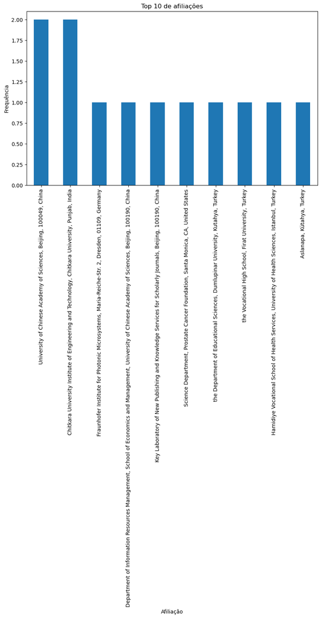

```python
# Instituições de afiliação - Top 10
df['Affiliations'] = df['Affiliations'].fillna('')
df['Affiliations'] = df['Affiliations'].str.strip()
#Excluir campos vazios
df = df[df['Affiliations'] != '']

all_affil = df['Affiliations'].str.split('; ').explode().value_counts().head(10)
print("Top 10 de afiliações:")
print(all_affil)

# Mostrar gráfico - Top 10
plt.figure(figsize=(10, 6))
all_affil.plot(kind='bar', title='Top 10 de afiliações')
plt.xlabel("Afiliação")
plt.ylabel("Frequência")
plt.show()
```

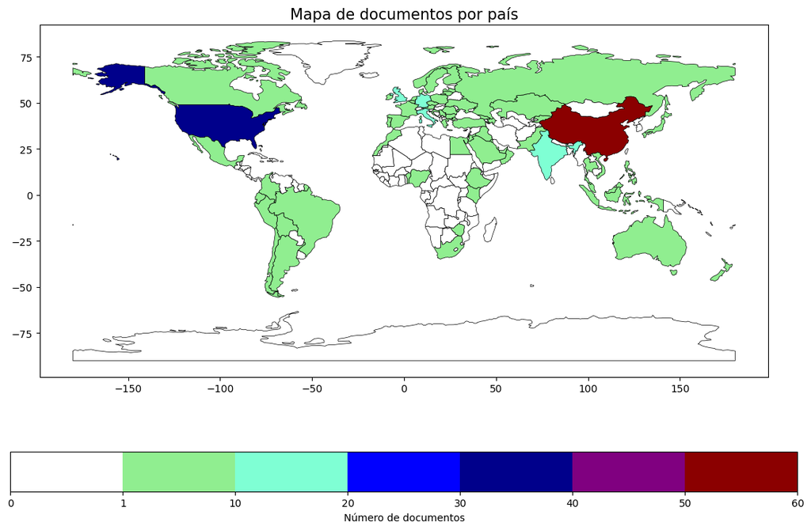

```python
# Distribuição de documentos por país
from matplotlib.colors import ListedColormap, BoundaryNorm
#Carregamento do shp do mapa mundo
world = gpd.read_file(gpd.datasets.get_path('naturalearth_lowres'))

country_mapping = {
    'United States': 'United States of America',
    #'United Kingdom': 'United Kingdom of Great Britain and Northern Ireland',
    'Russian Federation': 'Russia',
    'South Korea': 'Republic of Korea',
    'Czech Republic': 'Czechia',
    'Iran': 'Iran (Islamic Republic of)',
    'Hong Kong': 'Hong Kong Special Administrative Region of China',
    'Taiwan': 'Taiwan, Province of China',
    'Viet Nam': 'Vietnam',
    # 'Undefined' não tem correspondência e pode ser tratado separadamente
}

# Aplicar o mapeamento ao seu DataFrame
df_country['COUNTRY'] = df_country['COUNTRY'].replace(country_mapping)

# Mesclar os dados com o GeoDataFrame do mundo
merged = world.merge(df_country, how='left', left_on='name', right_on='COUNTRY')

# preencher valores vazios a 0 para os países do mundo surgirem
merged['NR_PUB'] = merged['NR_PUB'].fillna(0)

#dar cores aos valores
cmap = ListedColormap(['white','lightgreen', 'aquamarine', 'lightblue', 'blue', 'darkblue', 'purple', 'red', 'darkred'])
norm = BoundaryNorm([0, 1, 10, 20, 30, 40, 50, 60], cmap.N)

# Visualizar o mapa
ax = merged.plot(column='NR_PUB', legend=True, cmap=cmap, norm=norm, figsize=(14, 9),
                edgecolor="black", linewidth=0.5, legend_kwds={'label': "Número de documentos",
                'orientation': "horizontal"} )

ax.set_title('Mapa de documentos por país', fontdict={'fontsize': 15}, loc='center')
plt.show()
```

### 3.4. O quê?

Nesta secção analisa-se a distribuição dos documentos por tipologia, as palavras-chave mais frequentes e, por fim, a ocorrência dos termos de pesquisa (“artificial intelligence”, “scientific research” e “impact”) no campo Título.

```
Tipos de documento:
Document Type
Article             120
Conference paper     49
Review               40
Book chapter         20
Retracted             3
Note                  1
Short survey          1
Editorial             1
Letter                1
Book                  1
Name: count, dtype: int64
```

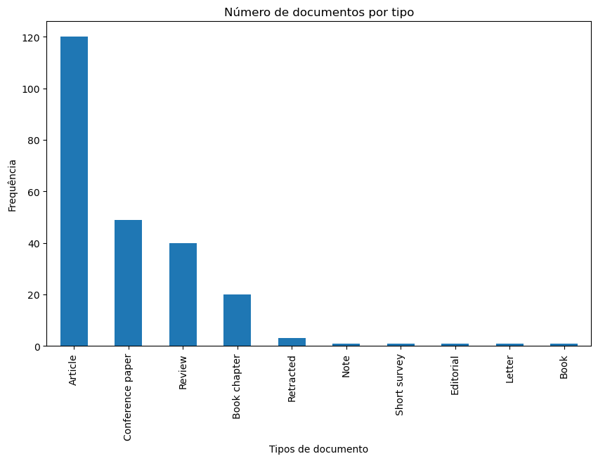

```python
# Tipos de documento

df['Document Type'] = df['Document Type'].fillna('')
all_keywords = df['Document Type'].str.split('; ').explode().value_counts().head(15)
print("Tipos de documento:")
print(all_keywords)

# Mostrar o top 10 de tipos de documento
plt.figure(figsize=(10, 6))
all_keywords.plot(kind='bar', title='Número de documentos por tipo')
plt.xlabel("Tipos de documento")
plt.ylabel("Frequência")
plt.show()
```

```
Top 10 de palavras-chave de autor:
Author Keywords
artificial intelligence    93
machine learning           25
chatgpt                    19
deep learning              13
big data                   10
education                   9
scientific research         8
research                    6
technology                  6
neural networks             5
Name: count, dtype: int64
```

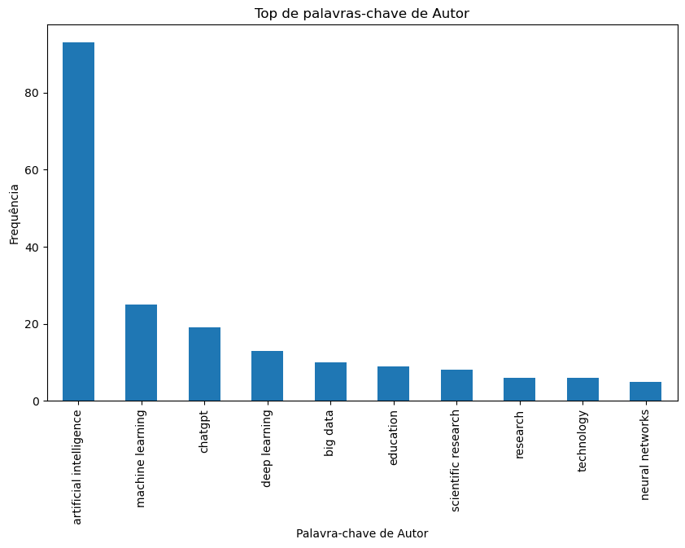

```python
# Palavras-chave de autor mais frequentes - Top 10
df1['Author Keywords'] = df1['Author Keywords'].fillna('')
df1['Author Keywords'] = df1['Author Keywords'].str.lower().str.strip()
#Excluir campos vazios
df1 = df1[df1['Author Keywords'] != '']

all_keywords = df1['Author Keywords'].str.split('; ').explode().value_counts().head(10)
print("Top 10 de palavras-chave de autor:")
print(all_keywords)

# Mostrar gráfico - Top 10
plt.figure(figsize=(10, 6))
all_keywords.plot(kind='bar', title='Top de palavras-chave de Autor')
plt.xlabel("Palavra-chave de Autor")
plt.ylabel("Frequência")
plt.show()
```

```
Top 10 de palavras-chave de indexação:
Index Keywords
artificial intelligence        120
scientific researches           56
human                           30
machine learning                29
deep learning                   23
humans                          22
decision making                 19
review                          17
natural language processing     12
machine-learning                12
Name: count, dtype: int64
```

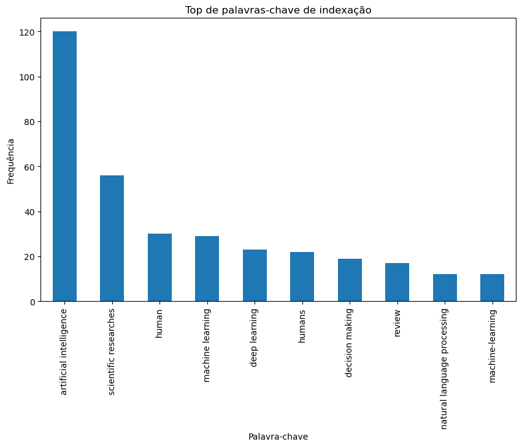

```python
# Palavras-chave de indexação mais frequentes
df['Index Keywords'] = df['Index Keywords'].fillna('')
df['Index Keywords'] = df['Index Keywords'].str.lower().str.strip()
#Excluir campos vazios
df = df[df['Index Keywords'] != '']

all_keywords = df['Index Keywords'].str.split('; ').explode().value_counts().head(10)
print("Top 10 de palavras-chave de indexação:")
print(all_keywords)

# Mostrar gráfico - Top 10
plt.figure(figsize=(10, 6))
all_keywords.plot(kind='bar', title='Top de palavras-chave de indexação')
plt.xlabel("Palavra-chave")
plt.ylabel("Frequência")
plt.show()
```

```python
# Ocorrência dos termos de pesquisa no campo Título
# Funçao
def contadordeexpressoes(frase1, frase2, frase3):
    cont = 0
    for title in df['Title']:
        if ((frase1.lower() and frase2.lower()) and frase3.lower()) in title.lower():
            cont +=1
    return cont

# Codigo
frase1 = "artificial intelligence"
frase2 = "scientific research"
frase3 = "impact"

contadorAI = contadordeexpressoes(frase1, frase2, frase3)

print(F"As expressões *{frase1}*, *{frase2}* e *{frase3}* surgem {contadorAI} vezes na coluna 'Title' da base de dados")
```

[output not shown]

## Possíveis aplicações de modelos/técnicas de *Machine Learning*

### Classificação da relevância dos documentos

**Classificação / algoritmo de aprendizagem supervisionada**

Com base num conjunto de dados de treino (metadados das publicações científicas), verificar a ocorrência dos termos de pesquisa no campo ‘Título’ e criar classes para os artigos pela sua relevância (ex.: ocorrência dos três termos em simultâneo – muito relevante; ocorrência de dois termos em simultâneo – relevante; ocorrência de apenas um termo – pouco relevante).

**Regressão / algoritmo de aprendizagem supervisionada**

Seria também útil atribuir uma ponderação diferente a cada termo de pesquisa, uma vez que alguns termos são mais significantes do que outros (ex.: os termos “artificial intelligence” e “scientific research” são mais pertinentes do que “impact”).

### Previsão do volume de publicação

**Regressão / algoritmo de aprendizagem supervisionada**

Com base num conjunto de dados de treino (evolução do volume de publicação dos últimos 2 anos), prever o número de documentos que serão publicados no próximo ano.